# 1_Scatterplots_Hisograms_Barplots

## Other important aesthetics for scatterplots

For this examples I am going to resort the the `mpg` dataset (miles-per-gallon), which contains data about the fuel economy of different cars.

It contains less points than the diamonds dataset and therefore illustrates better some concepts. Again, you may run `?mpg` to get specific information about the variables

We will use as x the variable `cty` (city miles per gallon) and as y the variable `hwy` (highway miles per gallon).

### `shape`

The `shape` aesthetics may be used with categorical variables and it assigns a different shape to each category. It can deal with a maximum of 6 categories. In the example below, the `SUV` class is simply not plotted because there are more than 6 categories, so the last one is simply ommited.

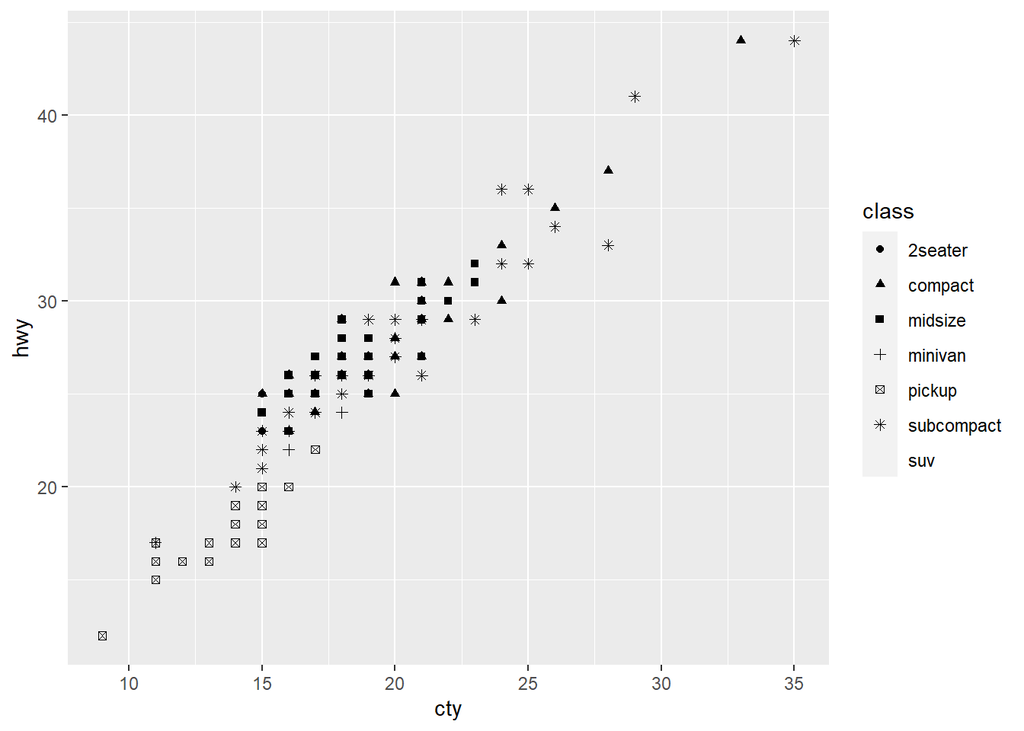

```r
mpg %>%
  ggplot(aes(cty, hwy)) +
  geom_point(aes(shape = class))
```

### `size`

The `size` aesthetic can be used with continuous or categorical variables, although with categoricals it does not make much sense, since categoricals do not necessarily have an implicit smaller than / greater than relationship (at least not directly). Let us use the number of engine cylinders as the `size` aesthetic:

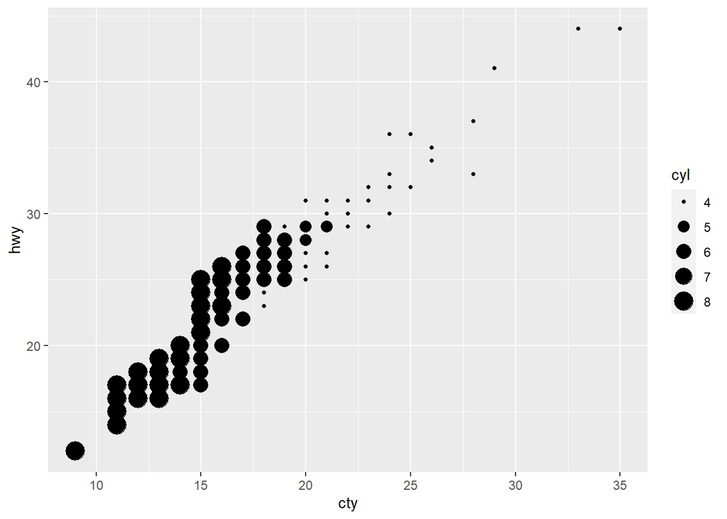

```r
mpg %>%
  ggplot(aes(cty, hwy)) +
  geom_point(aes(size = cyl))
```

## Exercise 1

Using the `mpg` dataset, create a scatterplot using `cty` as x (city miles per gallon) and `hwy` as y (highway miles per gallon). Then:

1. Colour the scatterplot using `displ` (engine displacement, in litres) as the mapping. Add a linear regression fit line. Expected output shown below:

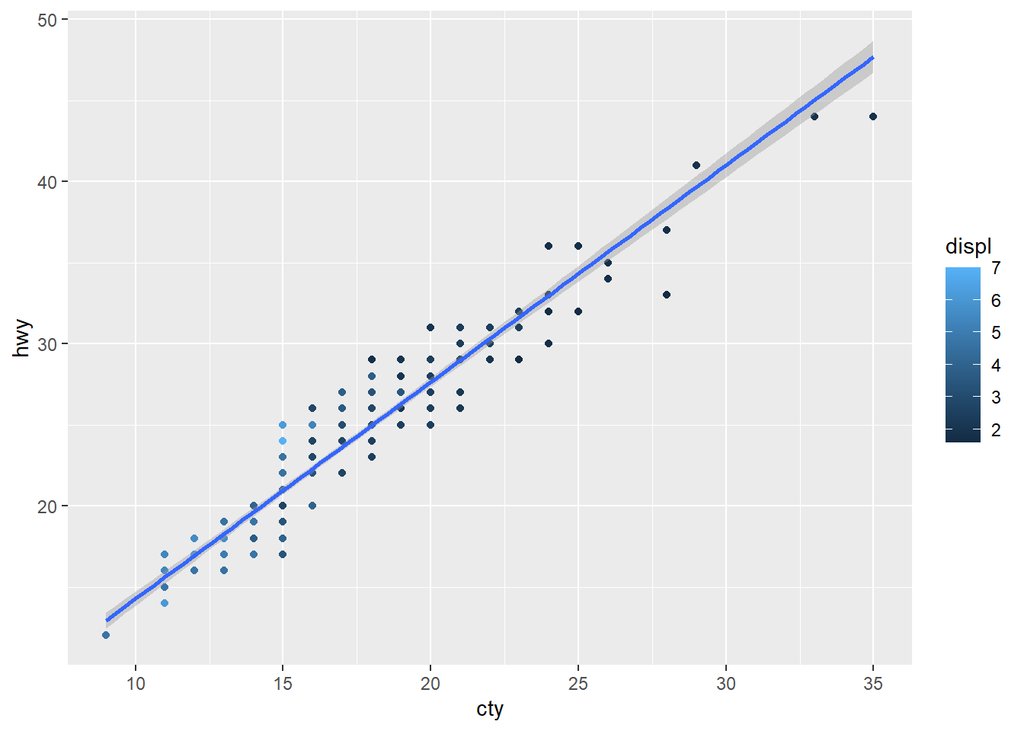

```r
mpg %>%
  ggplot(aes(cty, hwy)) +
  geom_point(aes(color = displ)) +
  geom_smooth(method = "lm")
```

2. Colour the scatterplot using `trans` (type of transmision) as the mapping. Add as well a linear regression fit line. Expected output shown below:

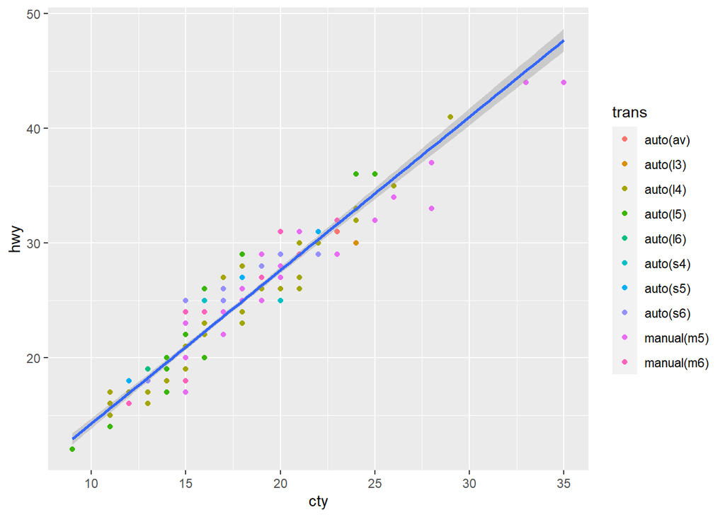

```r
mpg %>%
  ggplot(aes(cty, hwy)) +
  geom_point(aes(color = trans)) +
  geom_smooth(method = "lm")
```

3. Can you explain the difference in results?

```r
Depending on whether we color the graph following a continuous or a categorical
variable, we get a color gradient or just different colors.
```

```r
Another posibility to depict a third variable is to use size. This is most useful
when dealing with continuous variables, since categoricals do not necessarily have
an implicit ordering that allows you to define relationships such as "greater than"
or "smaller than".

For categoricals a similar alternative is shape.
```

## Exercise 2

Run the code below to generate a set of points corresponding to the function $y=x^2$. Then create a scatterplot using `geom_plot()` and overlay two `geom_smooth()` curves: one using a linear model and another one using a `loess` regression. **Provide an interpretation of the result**:

```r
x = seq(-5, 5, by=0.1)
y = x^2

df <- tibble(
        x = x,
        y = y
      )
```

Expected output:

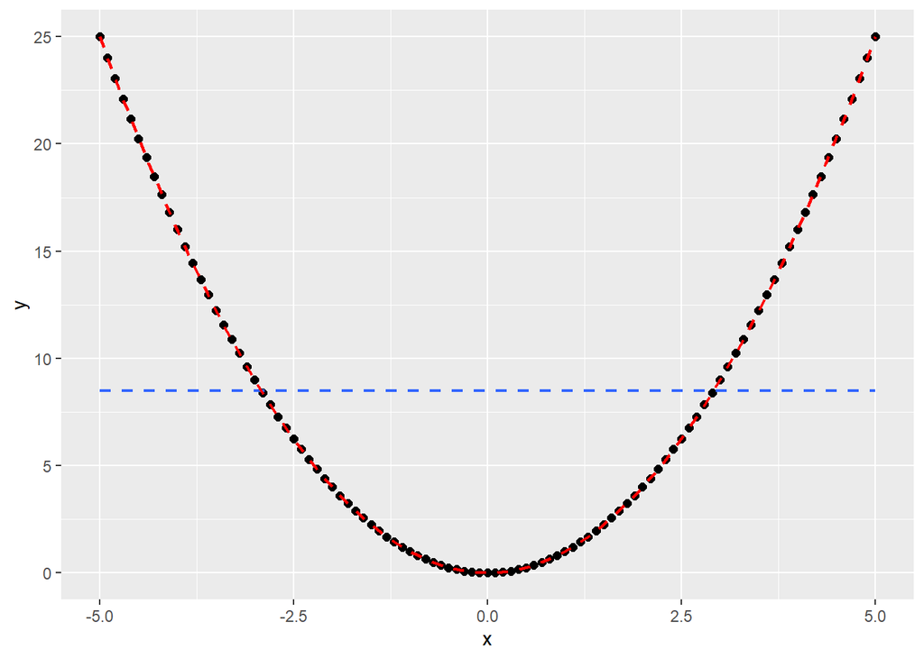

```r
ggplot(df, aes(x = x, y = y)) +
  geom_point(size = 2) +
  geom_smooth(method = "lm", linetype = "dashed", size = 0.8, se = FALSE) + # se: standard error
  geom_smooth(method = "loess", color = "red", linetype = "dashed", size = 0.8)
```

```r
The linear model returns a model with a correlation coefficient of 0 (slope 0).

But we know for a fact that there is a relationship between the two variables
since y = x^2. Remember that the correlation coefficient only captures linear
relationships. To capture the non-linear relationship we need to resort to the
loess or other non-linear model.
```

## Scatterplot matrices

The diagonal can be a histogram or a kernel density estimation for instance.

This is not part of the core materials of the subject, but these graphs are typically used to try to determine potential relationships between several variables visually.

Adding a non-linear smoothing curve can be useful to identify potential non-linearities:

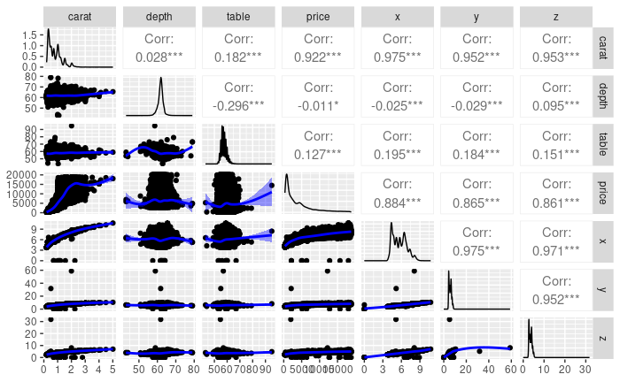

```r
my_fn <- function(data, mapping, ...){
  p <- ggplot(data = data, mapping = mapping) +
    geom_point() +
    geom_smooth(method="gam", fill="blue", color="blue", ...)
  p
}

g = ggpairs(diamonds %>% select(carat, depth, table, price, x, y, z),
            lower = list(continuous = my_fn))
g
```

# Histogram

Histograms require a **continuous numerical variable.**

Creating a histogram is just as easy, the main difference being that we now need to use `geom_histogram()`. We also no longer need to specify a `y` aesthetic.

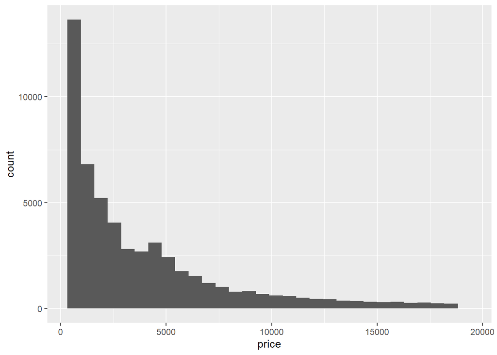

```r
ggplot(diamonds, aes(x = price)) +
  geom_histogram()
```

To color the histogram, we use the aesthetic `fill`. Using `color` would only affect the outline of each bar of the histogram

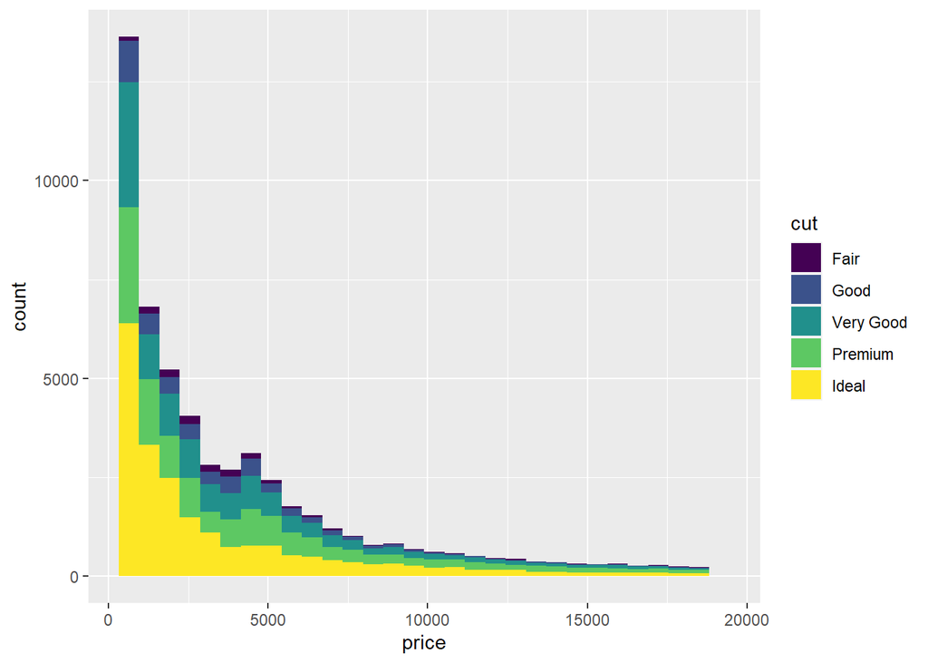

```r
ggplot(diamonds, aes(x = price, fill = cut)) +
  geom_histogram()
```

A first option is to filter the dataset. If we filter the dataset, we may create a histogram for only one of the cuts. First, lets remember how we can loop through the `unique()` values of the variable `cut` with a for loop (If you do not know how to use for loops in R, look for the syntax on reference 1 or refer to any online tutorial. The syntax below will suffice for our purposes though):

```r
for (cut in (diamonds$cut %>% unique())) {
  print(cut)
}
```

```
[1] "Ideal"
[1] "Premium"
[1] "Good"
[1] "Very Good"
[1] "Fair"
```

Now lets use that for loop produce different filtered versions of our dataset and then create a histogram of each of those sub-datasets (one histogram per cut type). We are going to use the function `list.append()` from the package `rlist` (be sure to install it if it is not available) to store the graph produced during each iteration of the for loop:

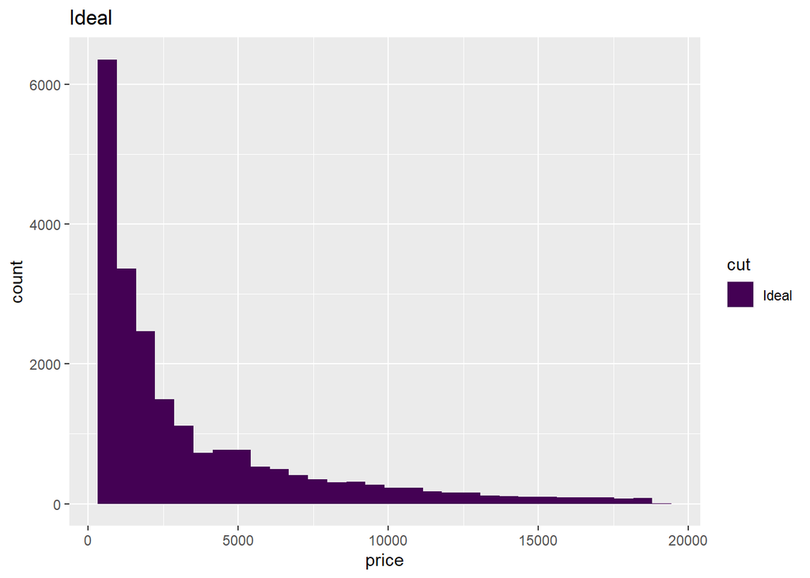

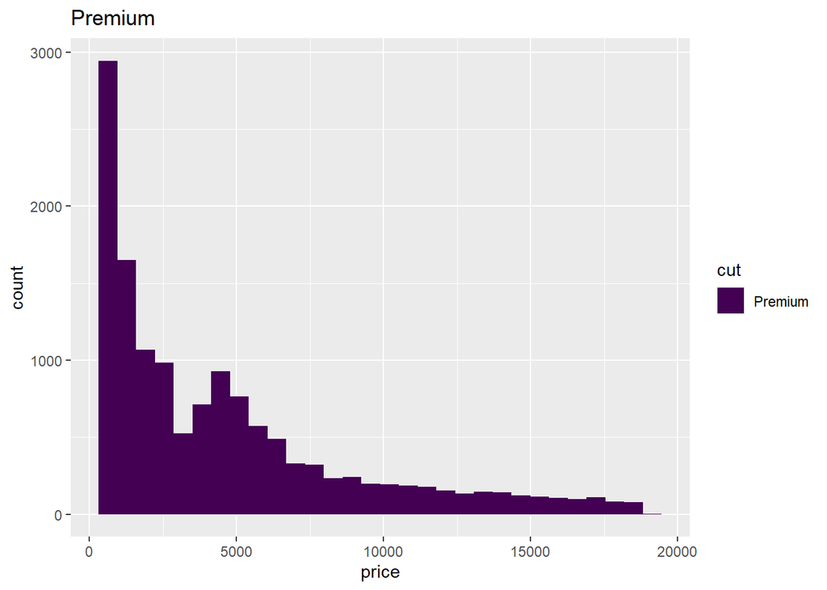

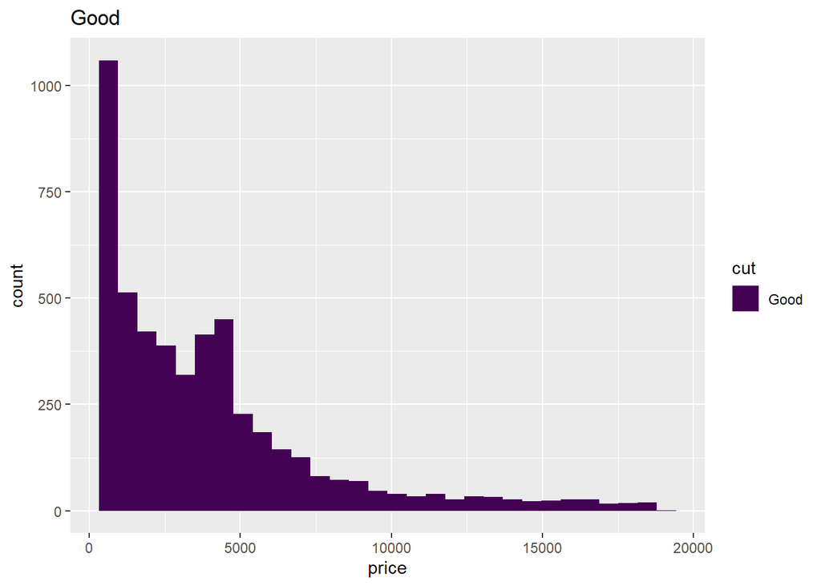

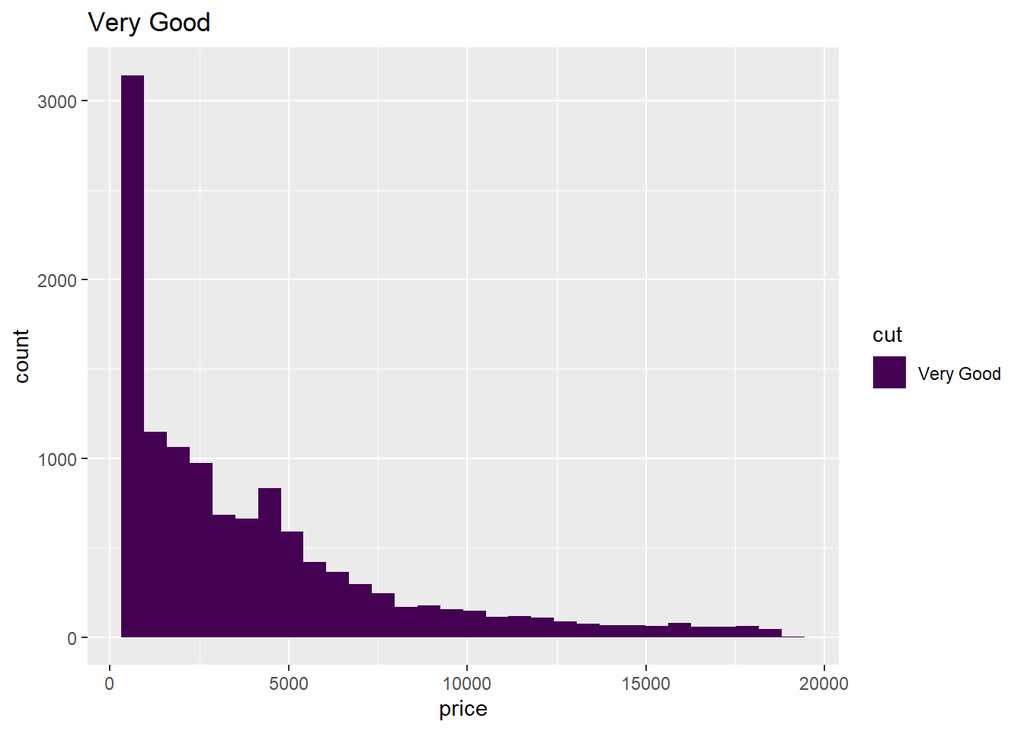

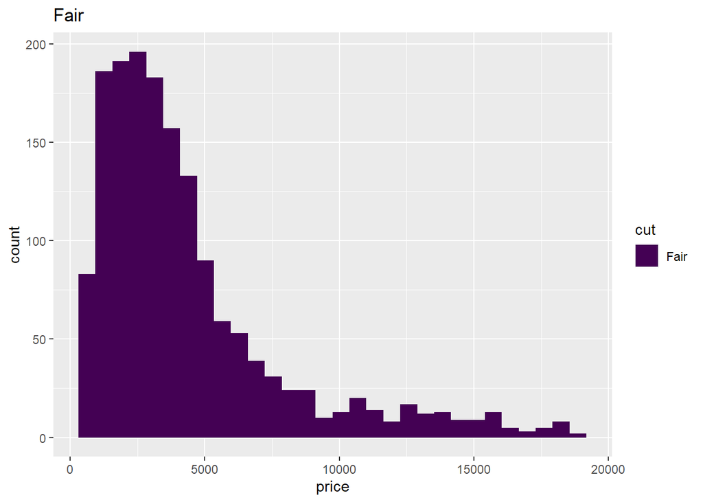

```r
# Initialize a list to store the output of the for loop
gr_list <- list()

for (cut_type in (diamonds$cut %>% unique())) {
  gr <- ggplot(data = diamonds %>% filter(cut == cut_type), aes(x = price, fill = cut)) +
          geom_histogram() +
          ggtitle(cut_type)

  # Store the graph in the list
  # The function list.append requires the package rlist
  gr_list <- gr_list %>% list.append(gr)
}

# Print all the graphs stored in the list
gr_list
```

## Faceting

We introduce here faceting in the context of histograms because it is an appropriate technique for the example at hand, but faceting is a **general technique to display/explore the effect of sub-setting the data by the values of a third categorical variable**. Essentially faceting does the following:

1. Subsets the data following the unique values of the specified categorical variable(s) (if more than one variable is specified, for all unique combinations of those variables).
2. Creates tables of graphs corresponding to those sub-datasets.

There are two faceting functions within ggplot2:

- `facet_wrap()`: use it when you want to split your data by one or more categorical variables and do not need a matrix-like ordered output (if you need a matrix-like order output, use `facet_grid()`).
- `facet_grid()`: use it when you want to split your data by 2 categorical variables. It has the additional advantage of providing a clear *matrix-like* ordered output.

`facet_wrap()` and `facet_grid()` are important and are better understood through examples, so lets see a bunch of them.

### `facet_wrap()` - examples

We specify a string within `facet_wrap` with the categorical variable by which we would like to subset the data:

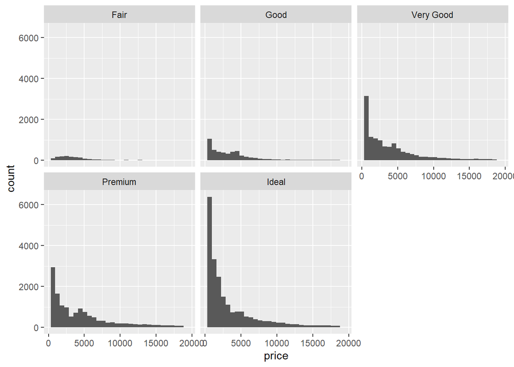

```r
ggplot(diamonds, aes(x=price)) +
  geom_histogram() +
  facet_wrap("cut")
```